# Modeling of the Impact of Temperature and Urchins on Kelp Percent Cover

## Model Heatmaps

We can look at the implications of our model in a number of ways. For example, if we compare how kelp will change given temperature change as we move from Downeast to York. The effects of urchins and temperature change because of the background conditions of each region.

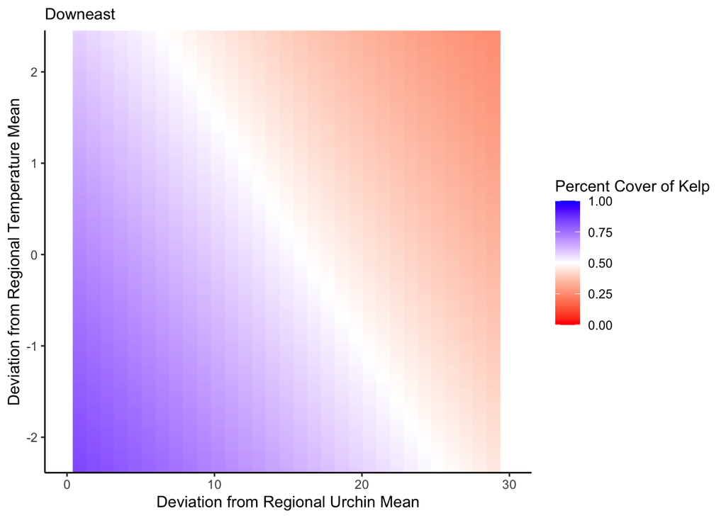

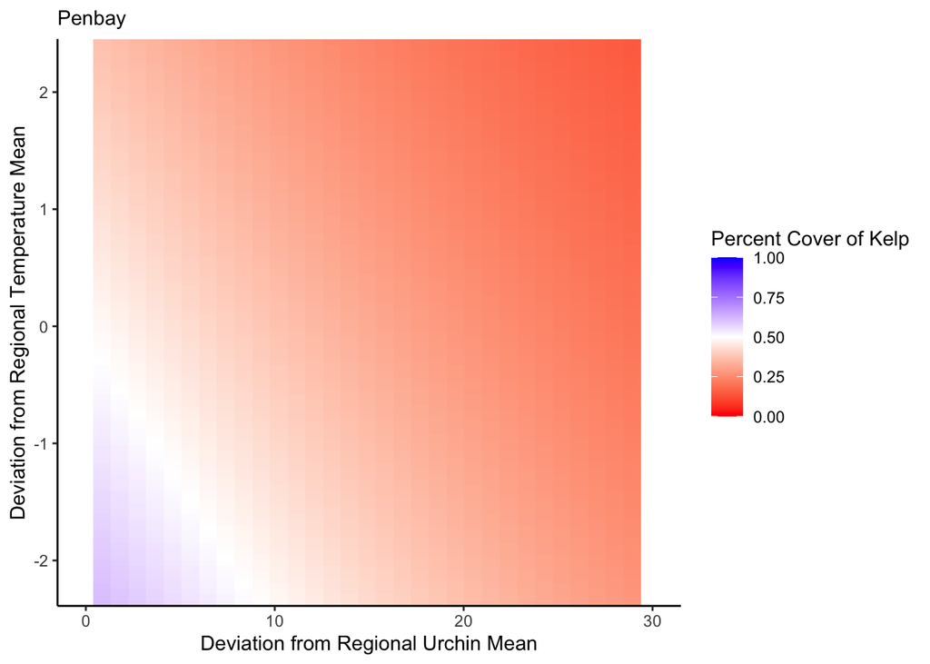

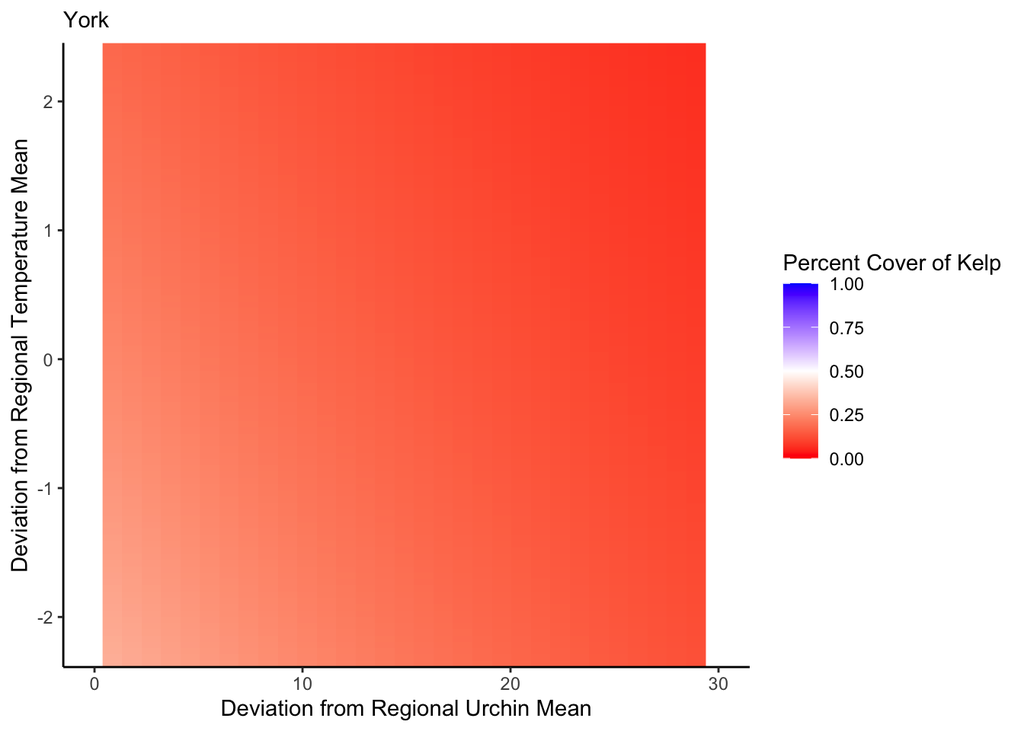

## How does Temperature Affect Regions in Different Ways at Different Urchin Densities

One way to explore the implication of our model is to evaluate how the different regions will respond to changing absolute temperatures given their current state and at different levels of urchins. In this figure, temperature is a combination of regional mean as well as deviation from mean (e.g., we took a temperature, and calculated the anomoly as difference of that temperature from regional mean). You can see that the impact of temperature differs by regions, even though the impact of urchins is similar.

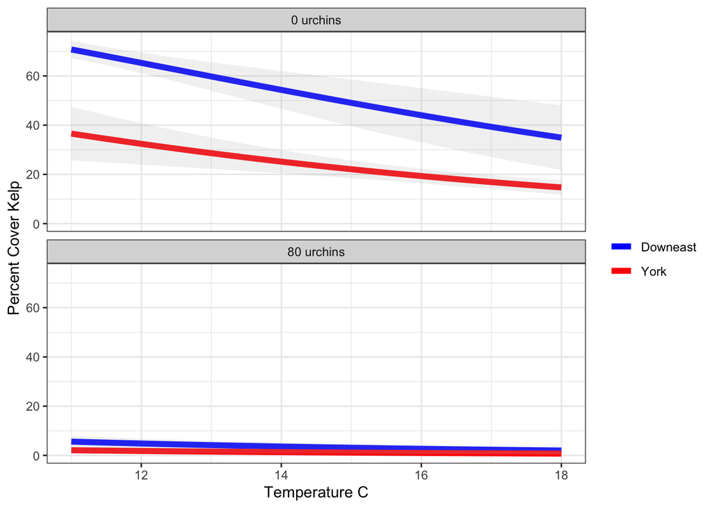

## Scenarios of Change

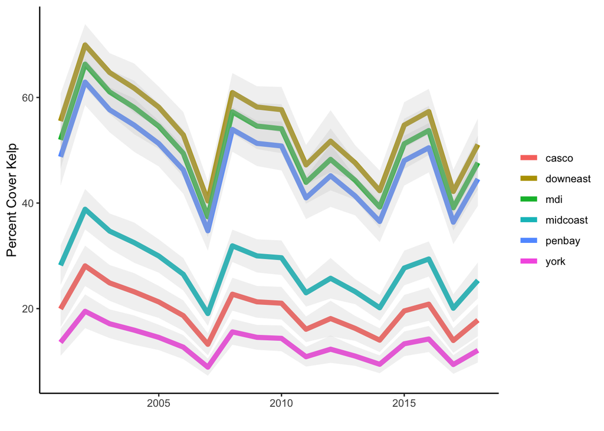

We can contrast this to how things played out in the data. Here, we use the scenario of taking the average temperature anomoly and average urchin anomoly and plot the resulting kelp abundances by year as predicted by the model. We see this reproduces similar dynamics to the raw data - temperature impact varies by region, even though urchins are in decline.

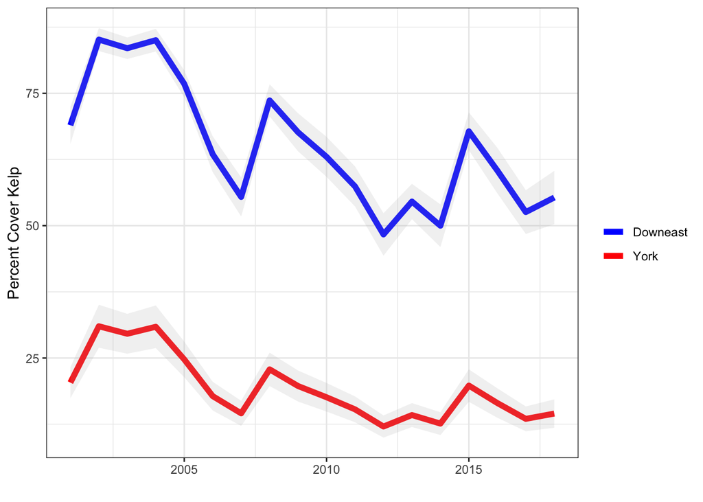

## Link Functions

While a complementary log-log plot makes sense in a system which experiences hysteresis, to be certain, we compared the additive model with a logit, probit, and cloglog link function. We find that the cloglog function clearly outperforms the others for this data set.

```
##                       dAIC df
## mod_urchin_add         0.0 8
## mod_urchin_add_logit   8.5 8
## mod_urchin_add_probit 11.2 8
```